# Analyze the vertical alignment of a long route (>10km)

Xiaoming Yang

2023-12-30

In a previosu article we have demonstrated the vertical_analysis() function on a sample route of about 11.6 km long. If the function is directly applied to a longer route, the tsoutliers() function tend to be less sensitive to erratic elevation and grade points, and the breakpoints() function tend to pickup more segments. It is not sure if the former leads to the other.

First, load required packages and function files.

```r
library(osmdata)
library(leaflet)
library(sf)
library(strucchange)
library(forecast)

source('fun_get_routes.R')
source('fun_get_elevation.R') #identify unique routes
source('fun_vertical_analysis.R') #horizontal alignment analysis
```

The following code extracts the 2D road geometry from OpenStreetMap(OSM). The sample route is I-75NB in Bartow County, Georgia.

```r
bbox <- getbb("Bartow County, Georgia")
county <- getbb("Bartow County, Georgia",format_out = "sf_polygon")

opq <- bbox %>% opq() %>%
  add_osm_feature(key = "highway", value = c("motorway")) %>%
  osmdata_sf()
roads <- opq$osm_lines %>%  st_intersection(county)

routes <- get_routes(roads)
route <- routes[2,]

leaflet() %>%
  addProviderTiles(providers$CartoDB.Positron) %>%
  addPolylines(data = route, color = palette(rainbow(nrow(routes))), weight = 3) %>%
  addScaleBar(position='bottomleft')
```

[interactive chart not shown]

Get the elevation data at 20m resolution for the whole route.

```r
route <- route %>%
          st_coordinates() %>% st_zm () %>%
          st_linestring() %>%
          st_sfc() %>%
          st_set_crs(4326)
routes_xyz <- get_elevation(route, 20)
```

```
## Requested 2412 elevation records from USGS. 1 records missing.
```

The following code analyze the long route by 10km sections. After every analysis, the last two segments are combined into the next section.

```r
lsec<-500
section<-routes_xyz %>% st_coordinates()
start<-1
end<-lsec
route2<-section[start:end,1:3]%>%
        st_linestring() %>%
        st_sfc() %>%
        st_set_crs(4326)
vr <- vertical_analysis(route2)
```

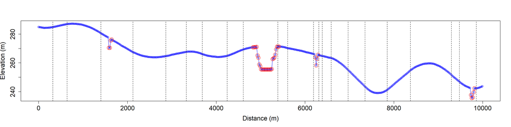

```
## 23 segments detected!
```

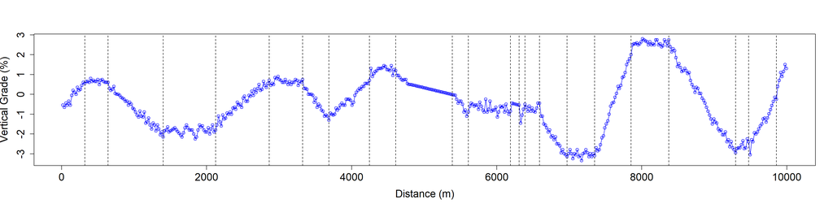

```r
start<- tail(vr,2)$from[1]
end<-min(start+lsec-1,nrow(section))

while (start<nrow(section)) {
  route2<-section[start:end,1:3]%>%
          st_linestring() %>%
          st_sfc() %>%
          st_set_crs(4326)
  vr2 <- vertical_analysis(route2)
  vr2 <- vr2 %>% mutate(from=from+start-1) %>% mutate(to=to+start-1)
  vr<-rbind(head(vr,-2),vr2)
  start<-tail(vr,2)$from[1]
  end<-start+lsec-1
  if (end>=nrow(section)) break
}
```

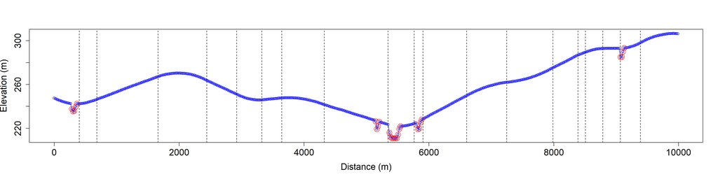

```
## 20 segments detected!
```

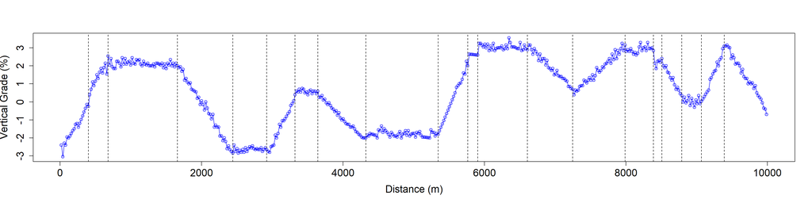

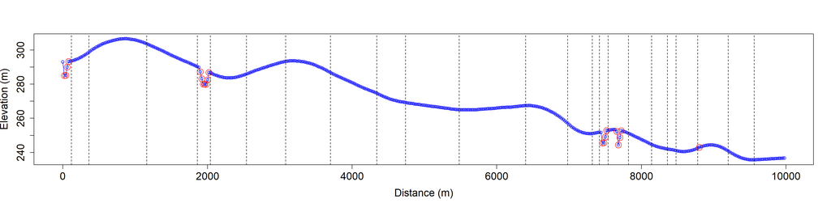

```
## 24 segments detected!
```

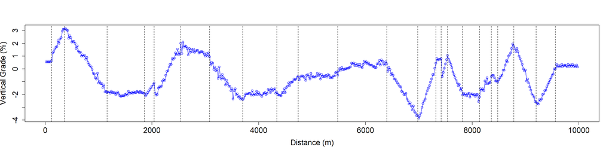

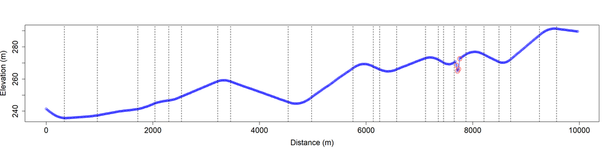

```
## 25 segments detected!
```

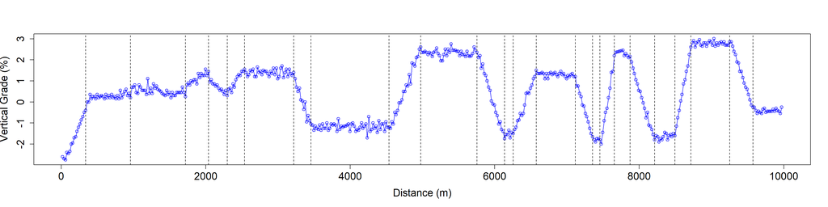

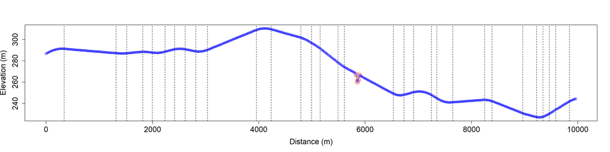

```
## 32 segments detected!
```

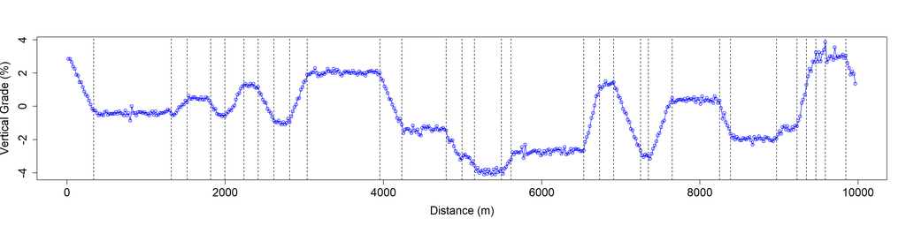

```r
route2<-section[start:nrow(section),1:3]%>%
        st_linestring() %>%
        st_sfc() %>%
        st_set_crs(4326)
vr2 <- vertical_analysis(route2)
```

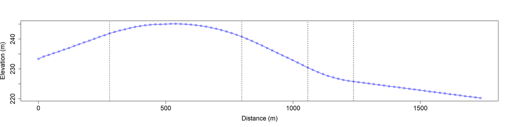

```
## 5 segments detected!
```

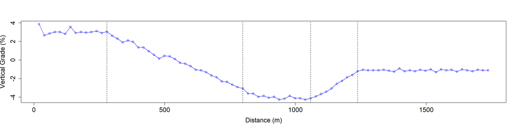

```r
vr2 <- vr2 %>% mutate(from=from+start-1) %>% mutate(to=to+start-1)
vr<-rbind(head(vr,-2),vr2)
```

Plot to see the result.

```r
vr <- vr %>% mutate(type = ifelse(r2 >= 0.5, "vc",
  ifelse((r2 < 0.5 & std <= 0.5)|is.na(r2), "vt", "u")))

leaflet() %>%
  addProviderTiles(providers$CartoDB.Positron) %>%
  addPolylines(data=vr[vr$type=="vc",]%>%st_zm(), color='red', weight = 4) %>%
  addPolylines(data=vr[vr$type=="vt",]%>%st_zm(), color='black', weight = 2) %>%
  addScaleBar(position='bottomleft')
```

[interactive chart not shown]

```r
leaflet() %>%
  addProviderTiles(providers$CartoDB.Positron) %>%
  addPolylines(data=vr[vr$type=="vc",]%>%st_zm(), color='red', weight = 2) %>%
  addPolylines(data=vr[vr$type=="vt",]%>%st_zm(), color='black', weight = 4) %>%
  addScaleBar(position='bottomleft')
```

[interactive chart not shown]

If we combine the result with horizontal analysis, we can generate some homogeneous segments:

- Horizontal tangent with a straight grade
- Entire horizontal curves with a straight grade
- Entire horizontal curves in a vertical curve

```r
vc<-vr[vr$type=="vc",]
vt<-vr[vr$type=="vt",]


source('fun_horizontal_analysis.R') #horizontal alignment analysis
```

```r
hr<-horizontal_analysis(route)
hc <- hr %>% filter(nmpd < 0.05) #h curves
ht <- hr %>% filter(is.na(nmpd)) #h tangents

# Horizontal tangent with a straight grade
c<-st_intersection(st_buffer(vt,2),ht)
```

```
## st_as_s2(): dropping Z and/or M coordinate
```

```r
c$len<-st_length(c)
htvt<- c %>% filter(as.numeric(len)>500)
leaflet() %>%
  addProviderTiles(providers$CartoDB.Positron) %>%
  addPolylines(data=htvt, color='black', weight = 2) %>%
  addScaleBar(position='bottomleft')
```

[interactive chart not shown]

```r
# Entire horizontal curves in a vertical tangent
hcvt<-st_contains(st_buffer(vt,2),hc)
```

```
## st_as_s2(): dropping Z and/or M coordinate
```

```r
leaflet() %>%
  addProviderTiles(providers$CartoDB.Positron) %>%
  addPolylines(data=hc[c(17,20),], color='blue', weight = 3) %>%
  addScaleBar(position='bottomleft')
```

[interactive chart not shown]

```r
# Entire horizontal curves in a vertical tangent
hcvc<-st_contains(st_buffer(vc,2),hc)
```

```
## st_as_s2(): dropping Z and/or M coordinate
```

```r
leaflet() %>%
  addProviderTiles(providers$CartoDB.Positron) %>%
  addPolylines(data=hc[12,], color='blue', weight = 4) %>%
  addPolylines(data=vc[26,]%>%st_zm(), color='red', weight = 1) %>%
  addScaleBar(position='bottomleft')
```

[interactive chart not shown]